# HAARVI DURT Panel Subpopulation Frequencies vs Status

Malisa Smith

version September 24, 2020

Perform statistical tests for the following subpopulations, stratified by Hospitalization status:

**Cell Populations (DURT panel)**:

CD14-CD19-CD3+ as % parent (T cells)  
CD56-CD19+CD14-CD3- as % parent (B cells)  
CD56-CD19-CD14+CD3- as % parent (Monocytes)  
CD56+CD19-CD14-CD3- as % parent (NK cells)

Monocyte:Lymphocytes (CD14+ : CD3+ U CD19+) (should be higher if more sick)

CD4 as % CD3  
CD8 as % CD3

CD4:CD8 ratio (should be higher if more sick)

Activated CD4 (HLA-DR+CD38+) as % CD4 Memory CD4 (Naive, TCM, TEM, TEMRA) as % CD4

Activated CD8 (HLA-DR+CD38+) as % CD8  
Memory CD8 (Naive, TCM, TEM, TEMRA) as % CD8

**DURTs**:

Total GD as % CD3  
Vd2+GD+ as % CD3  
Vd2-GD+ as % CD3

Activated GD (HLA-DR+CD38+) as % GD  
Activated Vd2+GD+ (HLA-DR+CD38+) as % Vd2+GD+  
Activated Vd2-GD+ (HLA-DR+CD38+) as % Vd2-GD+

Total MR1 as % CD3  
Activated MR1 (HLA-DR+CD38+) as % MR1

Total iNKT as % CD3  
Activated iNKT (HLA-DR+CD38+) as % iNKT

```r
library(openCyto) # 1.24.0
library(CytoML) # 1.12.0
library(flowCore) # required for description()
library(flowWorkspace) # required for gh_pop_get_data()
library(ggcyto) # devtools::install_github("RGLab/ggcyto", ref="ggplot3.3") for update_theme()
library(here)
library(tidyverse)
library(ggpubr)
library(grid)
library(gridExtra)
library(ggbeeswarm)
library(patchwork)
library(gsubfn)
```

# Read in GatingSet

```r
gs <- load_gs(here::here("out/GatingSets/20200812_HAARVI_DURT_GatingSet_AllBatches"))
```

```
## loading R object...
```

```
## loading tree object...
```

```
## Done
```

```r
save_output <- F
```

```r
pData(gs) %>% dplyr::filter(is.na(Cohort))
```

```
##  [1] name                          TUBE NAME
##  [3] EXPERIMENT NAME               $DATE
##  [5] SAMPLE ID                     filename
##  [7] rowname                       Sample ID
##  [9] Collection date               Cell count
## [11] Cohort                        Age
## [13] Sex                           Race
## [15] Hispanic?                     Days symptom onset to visit 1
## [17] Pair ID                       Race_v2
## [19] Batch
## <0 rows> (or 0-length row.names)
```

# Extract cell counts for populations of interest

```r
dput(gh_get_pop_paths(gs[[1]]))
```

```
## c("root", "/Time", "/Time/S", "/Time/S/Live", "/Time/S/Live/3+",
## "/Time/S/Live/3+/4+", "/Time/S/Live/3+/4+/CCR7+", "/Time/S/Live/3+/4+/CD45RA+",
## "/Time/S/Live/3+/8+", "/Time/S/Live/3+/8+/CCR7+", "/Time/S/Live/3+/8+/CD45RA+",
## "/Time/S/Live/3+/CD38+", "/Time/S/Live/3+/GD+", "/Time/S/Live/3+/GD+/Vd2+",
## "/Time/S/Live/3+/GD-", "/Time/S/Live/3+/HLADR+", "/Time/S/Live/14+",
## "/Time/S/Live/19+", "/Time/S/Live/56+", "/Time/S/Live/CD14-CD19-",
## "/Time/S/Live/CD14-CD19-/LD", "/Time/S/Live/CD14-CD19-/LD/Singlet",
## "/Time/S/Live/CD14-CD19-/LD/Singlet/56+", "/Time/S/Live/CD14-CD19-/LD/Singlet/CD3+",
## "/Time/S/Live/CD14-CD19-/LD/Singlet/CD3+/4+", "/Time/S/Live/CD14-CD19-/LD/Singlet/CD3+/4+/CCR7+",
## "/Time/S/Live/CD14-CD19-/LD/Singlet/CD3+/4+/CD45RA+", "/Time/S/Live/CD14-CD19-/LD/Singlet/CD3+/8+",
## "/Time/S/Live/CD14-CD19-/LD/Singlet/CD3+/8+/CCR7+", "/Time/S/Live/CD14-CD19-/LD/Singlet/CD3+/8+/CD45RA+",
## "/Time/S/Live/CD14-CD19-/LD/Singlet/CD3+/CD38+", "/Time/S/Live/CD14-CD19-/LD/Singlet/CD3+/GD+",
## "/Time/S/Live/CD14-CD19-/LD/Singlet/CD3+/GD+/Vd2+", "/Time/S/Live/CD14-CD19-/LD/Singlet/CD3+/GD-",
## "/Time/S/Live/CD14-CD19-/LD/Singlet/CD3+/HLADR+", "/Time/S/Live/CD14-CD19-/LD/Singlet/CD3+/iNKT",
## "/Time/S/Live/CD14-CD19-/LD/Singlet/CD3+/MAIT", "/Time/S/Live/iNKT",
## "/Time/S/Live/MAIT", "/Time/S/Live/NK_cells", "/Time/S/Live/Lymphocytes",
## "/Time/S/Live/CD14-CD19-/LD/Singlet/CD3+/GD+/Vd2-", "/Time/S/Live/CD14-CD19-/LD/Singlet/CD3+/4+/Naive",
## "/Time/S/Live/CD14-CD19-/LD/Singlet/CD3+/4+/TCM", "/Time/S/Live/CD14-CD19-/LD/Singlet/CD3+/4+/TEMRA",
## "/Time/S/Live/CD14-CD19-/LD/Singlet/CD3+/4+/TEM", "/Time/S/Live/CD14-CD19-/LD/Singlet/CD3+/8+/Naive",
## "/Time/S/Live/CD14-CD19-/LD/Singlet/CD3+/8+/TCM", "/Time/S/Live/CD14-CD19-/LD/Singlet/CD3+/8+/TEMRA",
## "/Time/S/Live/CD14-CD19-/LD/Singlet/CD3+/8+/TEM", "/Time/S/Live/HLADR+",
## "/Time/S/Live/CD38+", "/Time/S/Live/CD14-CD19-/LD/Singlet/CD3+/4+/HLADR+CD38+",
## "/Time/S/Live/CD14-CD19-/LD/Singlet/CD3+/8+/HLADR+CD38+", "/Time/S/Live/CD14-CD19-/LD/Singlet/CD3+/GD+/HLADR+CD38+",
## "/Time/S/Live/CD14-CD19-/LD/Singlet/CD3+/GD+/Vd2+/HLADR+CD38+",
## "/Time/S/Live/CD14-CD19-/LD/Singlet/CD3+/GD+/Vd2-/HLADR+CD38+",
## "/Time/S/Live/CD14-CD19-/LD/Singlet/CD3+/MAIT/HLADR+CD38+", "/Time/S/Live/CD14-CD19-/LD/Singlet/CD3+/iNKT/HLADR+CD38+"
## )
```

```r
pop_paths_of_interest <- c("/Time/S/Live", "/Time/S/Live/CD14-CD19-/LD/Singlet/CD3+/iNKT",
                           "/Time/S/Live/CD14-CD19-/LD/Singlet/CD3+/MAIT", "/Time/S/Live/CD14-CD19-/LD/Singlet/CD3+", "/Time/S/Live/19+",
                           "/Time/S/Live/14+", "/Time/S/Live/NK_cells", "/Time/S/Live/Lymphocytes", "/Time/S/Live/CD14-CD19-/LD/Singlet/CD3+/4+",
                           "/Time/S/Live/CD14-CD19-/LD/Singlet/CD3+/8+", "/Time/S/Live/CD14-CD19-/LD/Singlet/CD3+/GD+", "/Time/S/Live/CD14-CD19-/LD/Singlet/CD3+/GD+/Vd2+",
                           "/Time/S/Live/CD14-CD19-/LD/Singlet/CD3+/GD+/Vd2-", "/Time/S/Live/CD14-CD19-/LD/Singlet/CD3+/4+/Naive",
                           "/Time/S/Live/CD14-CD19-/LD/Singlet/CD3+/4+/TCM", "/Time/S/Live/CD14-CD19-/LD/Singlet/CD3+/4+/TEMRA",
                           "/Time/S/Live/CD14-CD19-/LD/Singlet/CD3+/4+/TEM", "/Time/S/Live/CD14-CD19-/LD/Singlet/CD3+/8+/Naive",
                           "/Time/S/Live/CD14-CD19-/LD/Singlet/CD3+/8+/TCM", "/Time/S/Live/CD14-CD19-/LD/Singlet/CD3+/8+/TEMRA",
                           "/Time/S/Live/CD14-CD19-/LD/Singlet/CD3+/8+/TEM",
                           "/Time/S/Live/CD14-CD19-/LD/Singlet/CD3+/4+/HLADR+CD38+", "/Time/S/Live/CD14-CD19-/LD/Singlet/CD3+/8+/HLADR+CD38+",
                           "/Time/S/Live/CD14-CD19-/LD/Singlet/CD3+/GD+/HLADR+CD38+", "/Time/S/Live/CD14-CD19-/LD/Singlet/CD3+/GD+/Vd2+/HLADR+CD38+",
                           "/Time/S/Live/CD14-CD19-/LD/Singlet/CD3+/GD+/Vd2-/HLADR+CD38+", "/Time/S/Live/CD14-CD19-/LD/Singlet/CD3+/MAIT/HLADR+CD38+",
                           "/Time/S/Live/CD14-CD19-/LD/Singlet/CD3+/iNKT/HLADR+CD38+")
new_names_pop_paths_of_interest <- c("Live", "iNKT",
                                     "MAIT", "T_cells", "B_cells",
                                     "Monocytes", "NK_cells", "Lymphocytes", "CD4",
                                     "CD8", "GD_Pos", "GD_Pos_Vd2_Pos",
                                     "GD_Pos_Vd2_Neg", "CD4_Naive",
                                     "CD4_TCM", "CD4_TEMRA",
                                     "CD4_TEM", "CD8_Naive",
                                     "CD8_TCM", "CD8_TEMRA",
                                     "CD8_TEM",
                                     "CD4_HLADR_Pos_CD38_Pos", "CD8_HLADR_Pos_CD38_Pos",
                                     "GD_Pos_HLADR_Pos_CD38_Pos", "GD_Pos_Vd2_Pos_HLADR_Pos_CD38_Pos",
                                     "GD_Pos_Vd2_Neg_HLADR_Pos_CD38_Pos", "MAIT_HLADR_Pos_CD38_Pos",
                                     "iNKT_HLADR_Pos_CD38_Pos")
pop_dat <- gs_pop_get_count_with_meta(gs,
                                      subpopulations = pop_paths_of_interest) %>%
  dplyr::select(Population, Count, "SAMPLE ID", "Cohort", "Age", "Sex", "Race_v2", "Hispanic?",
                "Days symptom onset to visit 1", "Batch") %>%
  pivot_wider(names_from = Population, values_from = Count) %>%
  rename_at(vars(all_of(pop_paths_of_interest)),
            ~ new_names_pop_paths_of_interest)
```

```
## Processing sample names..
```

```
## merging..
```

```
## Done
```

```r
head(pop_dat)
```

```
## # A tibble: 6 x 36
##   `SAMPLE ID` Cohort   Age Sex   Race_v2 `Hispanic?` `Days symptom o… Batch
##   <chr>       <chr>  <int> <chr> <chr>   <chr>       <chr>            <dbl>
## 1 21C         Non-h…    36 F     White   Y           26                   1
## 2 141C        Non-h…    67 F     White   N           52                   1
## 3 15548       Hospi…    58 F     White   N/A         46                   1
## 4 25C         Non-h…    52 F     White   N           48                   1
## 5 148C        Non-h…    56 M     White   N           72                   1
## 6 15575       Hospi…    43 F     White   N/A         59                   1
## # … with 28 more variables: Live <int>, iNKT <int>, MAIT <int>, T_cells <int>,
## #   B_cells <int>, Monocytes <int>, NK_cells <int>, Lymphocytes <int>,
## #   CD4 <int>, CD8 <int>, GD_Pos <int>, GD_Pos_Vd2_Pos <int>,
## #   GD_Pos_Vd2_Neg <int>, CD4_Naive <int>, CD4_TCM <int>, CD4_TEMRA <int>,
## #   CD4_TEM <int>, CD8_Naive <int>, CD8_TCM <int>, CD8_TEMRA <int>,
## #   CD8_TEM <int>, CD4_HLADR_Pos_CD38_Pos <int>, CD8_HLADR_Pos_CD38_Pos <int>,
## #   GD_Pos_HLADR_Pos_CD38_Pos <int>, GD_Pos_Vd2_Pos_HLADR_Pos_CD38_Pos <int>,
## #   GD_Pos_Vd2_Neg_HLADR_Pos_CD38_Pos <int>, MAIT_HLADR_Pos_CD38_Pos <int>,
## #   iNKT_HLADR_Pos_CD38_Pos <int>
```

```r
length(unique(pop_dat$`SAMPLE ID`)) == nrow(pop_dat)
```

```
## [1] TRUE
```

```r
table(pop_dat$Batch) # 20, 18, 17
```

```
##
##  1  2  3
## 20 18 17
```

```r
# if(save_output) {
#   write.csv(pop_dat, here::here("out/Cell_Subpopulation_Stats/20200812_HAARVI_DURT_Cell_Subpopulation_Counts.csv"), row.names = F)
#   # pop_dat <- read.csv(here::here("out/Cell_Subpopulation_Stats/20200812_HAARVI_DURT_Cell_Subpopulation_Counts.csv"), check.names = F, stringsAsFactors = F)
# }
```

# Perform statistical tests vs status

```r
pop_dat <- pop_dat %>%
  mutate(T_div_Live = T_cells / Live,
         B_div_Live = B_cells / Live,
         Monocytes_div_Live = Monocytes / Live,
         NK_div_Live = NK_cells / Live,
         Monocytes_Lymphocytes_ratio = Monocytes / Lymphocytes,
         CD4_div_T = CD4 / T_cells,
         CD8_div_T = CD8 / T_cells,
         HLADR_CD38_div_CD4 = CD4_HLADR_Pos_CD38_Pos / CD4,
         Naive_div_CD4 = CD4_Naive / CD4,
         TCM_div_CD4 = CD4_TCM / CD4,
         TEMRA_div_CD4 = CD4_TEMRA / CD4,
         TEM_div_CD4 = CD4_TEM / CD4,
         HLADR_CD38_div_CD8 = CD8_HLADR_Pos_CD38_Pos / CD8,
         Naive_div_CD8 = CD8_Naive / CD8,
         TCM_div_CD8 = CD8_TCM / CD8,
         TEMRA_div_CD8 = CD8_TEMRA / CD8,
         TEM_div_CD8 = CD8_TEM / CD8,
         GD_div_T = GD_Pos / T_cells,
         GD_Vd2Pos_div_T = GD_Pos_Vd2_Pos / T_cells,
         GD_Vd2Neg_div_T = GD_Pos_Vd2_Neg / T_cells,
         HLADR_CD38_div_GD = GD_Pos_HLADR_Pos_CD38_Pos / GD_Pos,
         HLADR_CD38_div_GD_Vd2Pos = GD_Pos_Vd2_Pos_HLADR_Pos_CD38_Pos / GD_Pos_Vd2_Pos,
         HLADR_CD38_div_GD_Vd2Neg = GD_Pos_Vd2_Neg_HLADR_Pos_CD38_Pos / GD_Pos_Vd2_Neg,
         MAIT_div_T = MAIT / T_cells,
         HLADR_CD38_div_MAIT = MAIT_HLADR_Pos_CD38_Pos / MAIT,
         iNKT_div_T = iNKT / T_cells,
         HLADR_CD38_div_iNKT = iNKT_HLADR_Pos_CD38_Pos / iNKT,
         CD4_CD8_ratio = CD4 / CD8,
         Vd2_div_GD = GD_Pos_Vd2_Pos / GD_Pos)
cols_to_test <- c("T_div_Live", "B_div_Live", "Monocytes_div_Live",
                  "NK_div_Live", "Monocytes_Lymphocytes_ratio", "CD4_div_T", "CD8_div_T", "HLADR_CD38_div_CD4",
                  "Naive_div_CD4", "TCM_div_CD4", "TEMRA_div_CD4", "TEM_div_CD4",
                  "HLADR_CD38_div_CD8", "Naive_div_CD8", "TCM_div_CD8", "TEMRA_div_CD8",
                  "TEM_div_CD8", "GD_div_T", "GD_Vd2Pos_div_T", "GD_Vd2Neg_div_T",
                  "HLADR_CD38_div_GD", "HLADR_CD38_div_GD_Vd2Pos", "HLADR_CD38_div_GD_Vd2Neg",
                  "MAIT_div_T", "HLADR_CD38_div_MAIT", "iNKT_div_T", "HLADR_CD38_div_iNKT",
                  "CD4_CD8_ratio", "Vd2_div_GD")
pop_dat_sub <- pop_dat %>%
  dplyr::filter(Cohort %in% c("Non-hospitalized", "Hospitalized")) %>%
  rename(Days_Symptom_Onset_to_Visit_1 = `Days symptom onset to visit 1`) %>%
  mutate(Days_Symptom_Onset_to_Visit_1 = as.numeric(Days_Symptom_Onset_to_Visit_1),
         Cohort = factor(Cohort, levels = c("Hospitalized", "Non-hospitalized")))
mannwhitney_results <- lapply(cols_to_test, function(col) {
  mw <- wilcox.test(as.formula(sprintf("%s ~ Cohort", col)),
                    data = pop_dat_sub)
  p.unadj <- mw$p.value
  med_nonhosp <- median(pop_dat_sub %>% dplyr::filter(Cohort == "Non-hospitalized") %>% dplyr::pull(!!col))
  med_hosp <- median(pop_dat_sub %>% dplyr::filter(Cohort == "Hospitalized") %>% dplyr::pull(!!col))
  fc <- med_hosp / med_nonhosp
  list(mw = mw,
       p.unadj = p.unadj,
       med_nonhosp = med_nonhosp,
       med_hosp = med_hosp,
       fc = fc)
})
names(mannwhitney_results) <- cols_to_test

# Perform Bonferroni p-value adjustments within each "subgroup" of multiple comparisons
multiple_comparisons_group_assignment <- c("T_div_Live" = 1, "B_div_Live" = 1, "Monocytes_div_Live" = 1, "NK_div_Live" = 1,
                                           "Monocytes_Lymphocytes_ratio" = 2,
                                           "CD4_div_T" = 3, "CD8_div_T" = 3,
                                           "HLADR_CD38_div_CD4" = 4, "Naive_div_CD4" = 4, "TCM_div_CD4" = 4, "TEMRA_div_CD4" = 4, "TEM_div_CD4" = 4,
                                           "HLADR_CD38_div_CD8" = 5, "Naive_div_CD8" = 5, "TCM_div_CD8" = 5, "TEMRA_div_CD8" = 5, "TEM_div_CD8" = 5,
                                           "GD_div_T" = 6, "GD_Vd2Pos_div_T" = 6, "GD_Vd2Neg_div_T" = 6,
                                           "HLADR_CD38_div_GD" = 7, "HLADR_CD38_div_GD_Vd2Pos" = 7, "HLADR_CD38_div_GD_Vd2Neg" = 7,
                                           "MAIT_div_T" = 8, "HLADR_CD38_div_MAIT" = 8,
                                           "iNKT_div_T" = 9, "HLADR_CD38_div_iNKT" = 9,
                                           "CD4_CD8_ratio" = 10,
                                           "Vd2_div_GD" = 11)
p_adj_df <- as.data.frame(multiple_comparisons_group_assignment) %>%
  rownames_to_column(var="comparisonCol") %>%
  mutate(p.unadj = sapply(mannwhitney_results, function(mwr) {mwr$p.unadj})) %>%
  group_by(multiple_comparisons_group_assignment) %>%
  mutate(p.adj = p.adjust(p.unadj, method="bonferroni"),
         multiple_comparisons_group_size = n()) %>%
  ungroup()
p_adj_df %>%
  arrange(p.adj) %>%
  head()
```

```
## # A tibble: 6 x 5
##   comparisonCol     multiple_comparisons_g… p.unadj   p.adj multiple_comparison…
##   <chr>                               <dbl>   <dbl>   <dbl>                <int>
## 1 HLADR_CD38_div_C…                       5 0.00148 0.00738                    5
## 2 HLADR_CD38_div_G…                       7 0.0102  0.0307                     3
## 3 Naive_div_CD8                           5 0.00788 0.0394                     5
## 4 HLADR_CD38_div_GD                       7 0.0148  0.0445                     3
## 5 HLADR_CD38_div_G…                       7 0.0158  0.0473                     3
## 6 HLADR_CD38_div_C…                       4 0.0237  0.119                      5
```

```r
if(save_output) {
  # Save frequencies (but as percents) and ratios to a file, for integrated analysis with ICS and Ab data
  # These columns can be read in separately:, "Cohort", "Age", "Sex", "Race_v2", "Hispanic?", "Days_Symptom_Onset_to_Visit_1"
  pop_dat_sub_2save <- pop_dat_sub %>%
    dplyr::select("SAMPLE ID", all_of(cols_to_test)) %>%
    mutate_at(vars(grep("_div_", cols_to_test, value=T)), ~ . * 100) %>%
    rename_at(vars(grep("_div_", cols_to_test, value=T)), ~ sub("_div_", "_pct_", .)) %>%
    rename("SAMPLE_ID" = "SAMPLE ID") %>%
    # Convert the numeric columns to character type after rounding to 20 digits. This will help ensure consistency when writing and reading the data to a file
    mutate_at(vars(-"SAMPLE_ID"), ~ format(., digits = 20))
  write.csv(pop_dat_sub_2save, here::here("processed_data/20200812_HAARVI_DURT_Cell_Population_Percents.csv"), row.names = F)
  # pop_dat_sub_2save <- read.csv(here::here("processed_data/20200812_HAARVI_DURT_Cell_Population_Percents.csv"), stringsAsFactors = F)
  # all.equal(pop_dat_sub_2save %>% mutate_at(vars(-"SAMPLE_ID"), as.numeric),
  #  read.csv(here::here("processed_data/20200812_HAARVI_DURT_Cell_Population_Percents.csv"), stringsAsFactors = F))
}
```

# Plot results

```r
# Arial font setup. Downloaded afms from https://github.com/microsoft/microsoft-r-open/tree/ec3fd89e5fb5794bd8149905c134ad801bb61800
Arial <- Type1Font(family = "Arial",
                   metrics = c(here::here("data/Arial_afm/ArialMT.afm"),
                               here::here("data/Arial_afm/ArialMT-Bold.afm"),
                               here::here("data/Arial_afm/ArialMT-Italic.afm"),
                               here::here("data/Arial_afm/ArialMT-BoldItalic.afm")))
pdfFonts(Arial = Arial)

# CohortColors <- c("Hospitalized" = "#707ed4", "Non-hospitalized" = "#c1ddd7")
# CohortOutlineColors <- c("Hospitalized" = "#5768d4", "Non-hospitalized" = "#95dbcc")
CohortColors <- c("Hospitalized" = "#757bbcb2", "Non-hospitalized" = "#b0d2c8bf")
CohortOutlineColors <- c("Hospitalized" = "#757bbbff", "Non-hospitalized" = "#b0d1c8ff")

text_sub_list <- list("GD" = "\u03B3\u03B4", "Vd2" = "V\u03B42", "HLADR" = "HLA-DR", "Pos" = "")

plot_result <- function(col) {
  current_p_unadj <- mannwhitney_results[[col]]$p.unadj
  current_p_adj <- p_adj_df %>% dplyr::filter(comparisonCol == col) %>% dplyr::pull(p.adj)
  p.adj.text <- if(current_p_adj < 0.001) { "p<.001"} else if(current_p_adj == 1) {"p=1.0"} else { paste0("p=", round(current_p_adj, 3)) }
  pop1 <- gsubfn(paste(names(text_sub_list),collapse="|"), text_sub_list, sub("(.*)_div_.*", "\\1", col))
  pop2 <- gsubfn(paste(names(text_sub_list),collapse="|"), text_sub_list, sub(".*_div_(.*)", "\\1", col))
  current_ylab <- if(col == "Monocytes_Lymphocytes_ratio") {
    "Monocytes:Lymphocytes"
  } else if(col == "CD4_CD8_ratio") {
      "CD4:CD8"
  } else {
      sprintf("%% %s\nof %s cells", sub("_", " ", pop1), sub("_", " ", pop2))
  }
  plot <- ggplot(pop_dat_sub, aes(Cohort, !!as.name(col))) +
    theme_bw(base_size = 22) +
    # Cannot figure out straightforward way to get outline color different from quantile line colors
    geom_violin(aes(fill = Cohort), draw_quantiles = c(0.5), color = "black",
              # All violins have the same maximum width. Overrides default of equal area
              scale="width", width=0.6) +
    geom_violin(fill="transparent", color="black", draw_quantiles = c(0.25, 0.75), linetype = "dashed",
                scale="width", width=0.6) +
    geom_violin(aes(color=Cohort), fill="transparent",
              scale="width", width=0.6, size=1.5) +
    # geom_beeswarm may result in points being plotted out of the violin bounds for certain very dense plots (e.g. TEMRA_div_CD4), so use geom_quasirandom instead
    # geom_beeswarm(size=0.5, cex=3.5, priority = "random") +
    geom_quasirandom(size=0.5, width=0.3, varwidth=T, method="quasirandom") +
    theme(axis.title.x = element_blank(),
            axis.title.y = element_text(size=22),
            axis.text.y = element_text(color="black", size=21),
            axis.text.x = element_text(color="black", size=21),
            plot.title = element_text(hjust = 0.5, size=22),
            panel.grid = element_blank(),
            legend.position = "none",
            plot.margin = margin(0.3, 0.2, 0.1, 0.2, "cm")) +
    scale_x_discrete(labels=c("Non-hospitalized" = "NH", "Hospitalized" = "H"), expand = c(0.3, 0.3)) +
    labs(y = current_ylab) +
    scale_fill_manual(values = CohortColors) +
    scale_color_manual(values = CohortOutlineColors)
  plot_ylims <- ggplot_build(plot)$layout$panel_params[[1]]$y.range
  plot_ylims[2] <- plot_ylims[2] + 0.08*diff(plot_ylims)
  plot <- plot +
    annotate("text", x = 1.5, y = plot_ylims[1] + 0.97*diff(plot_ylims), label = p.adj.text, size=7)
  if(col %in% c("Monocytes_Lymphocytes_ratio", "CD4_CD8_ratio")) {
    plot <- plot + scale_y_continuous(limits = plot_ylims)
  } else {
    plot <- plot + scale_y_continuous(labels = function(x) paste0(x*100), limits = plot_ylims)
  }
  plot
}

freqs_vs_cohort_plots <- lapply(cols_to_test, plot_result)
names(freqs_vs_cohort_plots) <- cols_to_test

# Make the width of all plots the same
# Help from here https://stackoverflow.com/a/41242871
gl <- lapply(freqs_vs_cohort_plots, ggplotGrob)
wd <- do.call(unit.pmax, lapply(gl, "[[", 'widths')) # Grab the width of the plot which has the largest width
freqs_vs_cohort_plots_grid <- lapply(gl, function(x) {
  x[['widths']] = wd
  x})
```

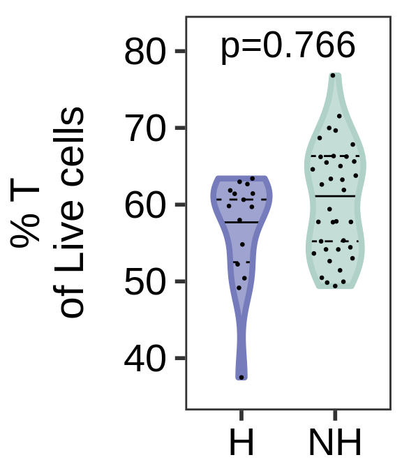

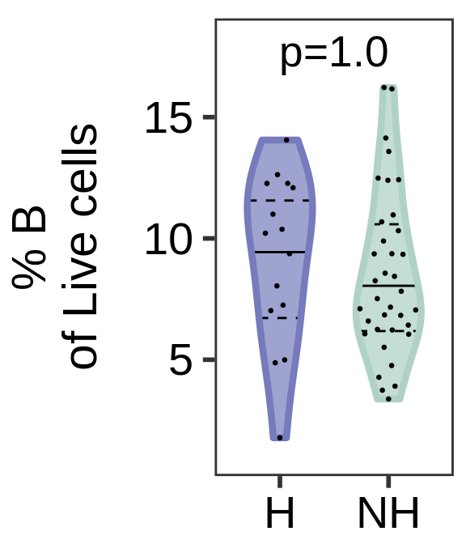

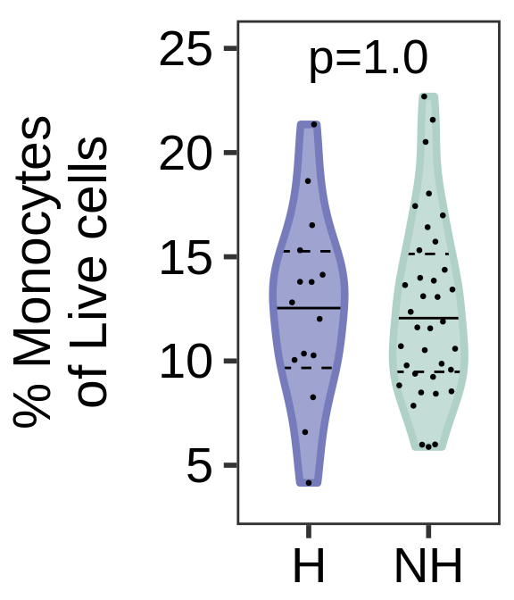

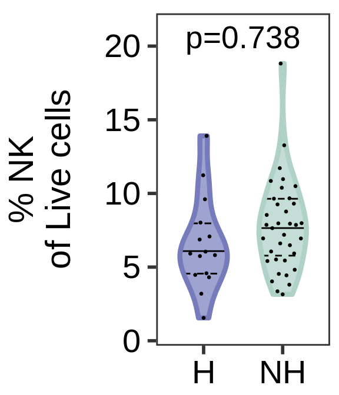

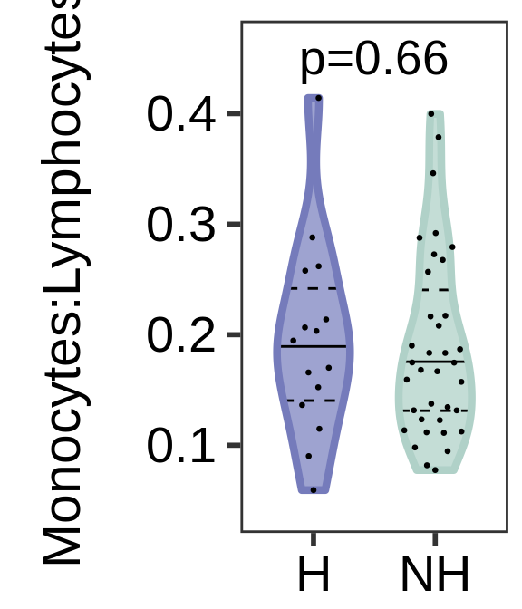

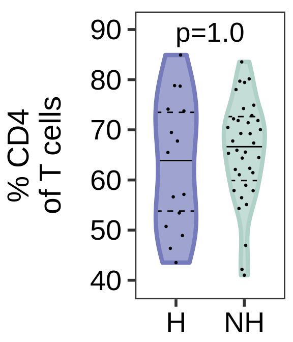

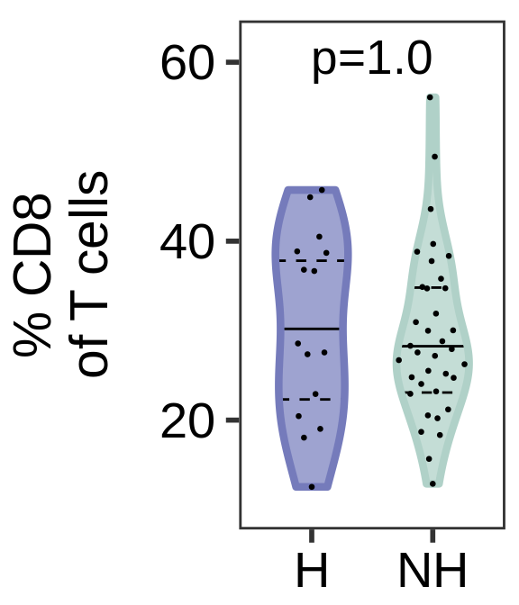

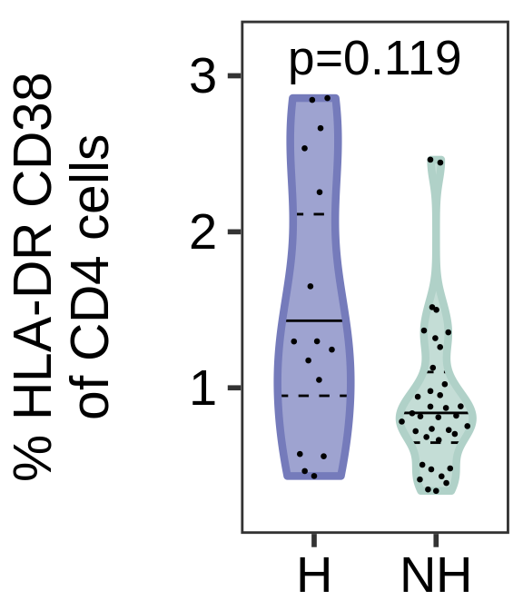

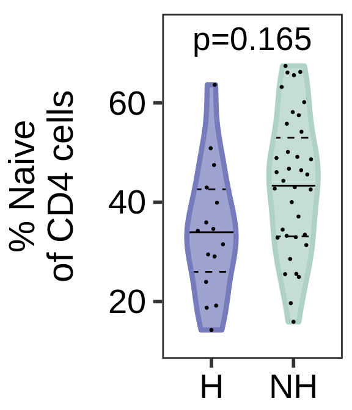

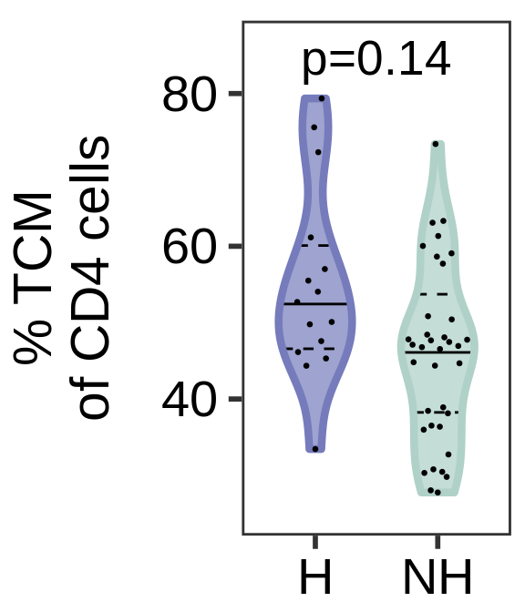

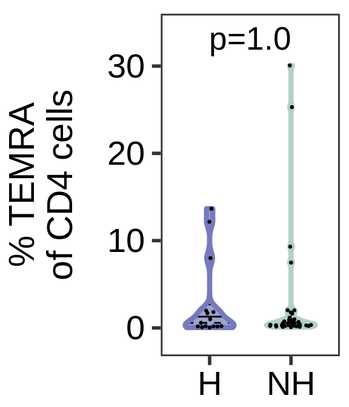

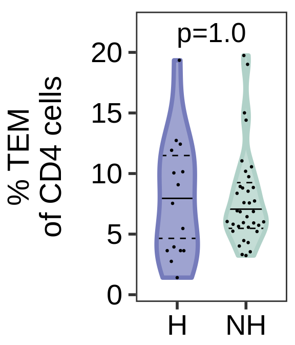

[17 more figures not shown]

```r
for(col in cols_to_test) {
  grid.arrange(freqs_vs_cohort_plots_grid[[col]])
}
```

# Regress Frequencies vs Days from Symptom Onset

Regress the following quantities vs Days-from-Symptom-Onset:  
- Total T cells, CD4, CD8, CD4:CD8, M:L  
- HLA-DR+CD38+ of CD4  
- HLA-DR+CD38+ of CD8

## Draw scatter plots

Colored by Hospitalization status

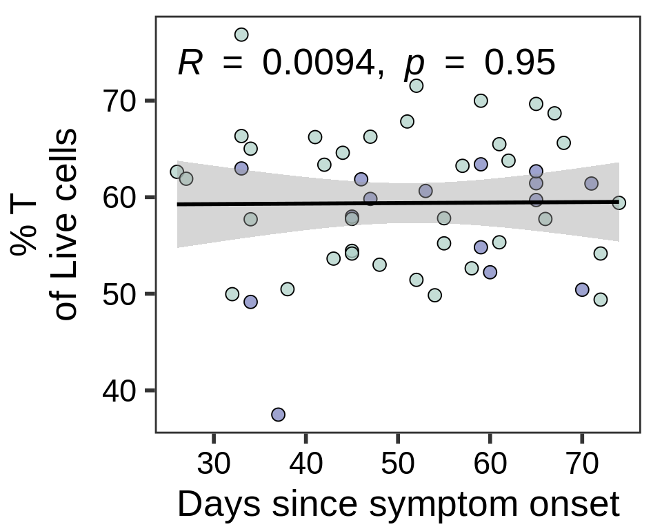

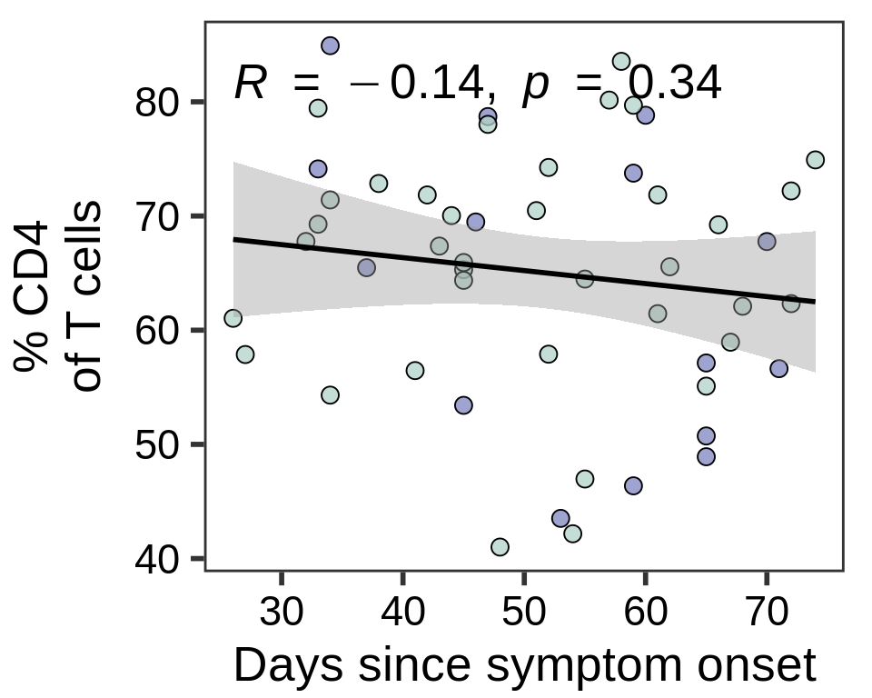

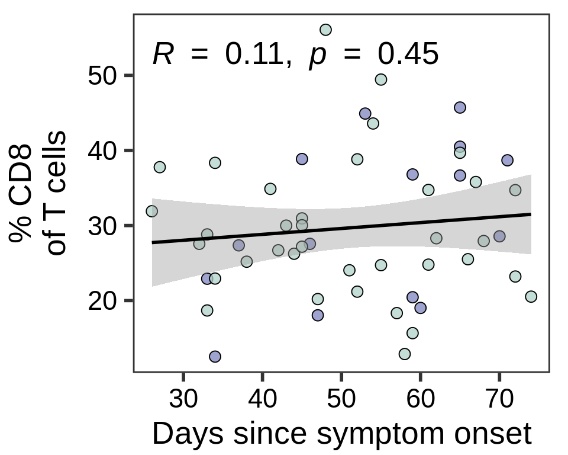

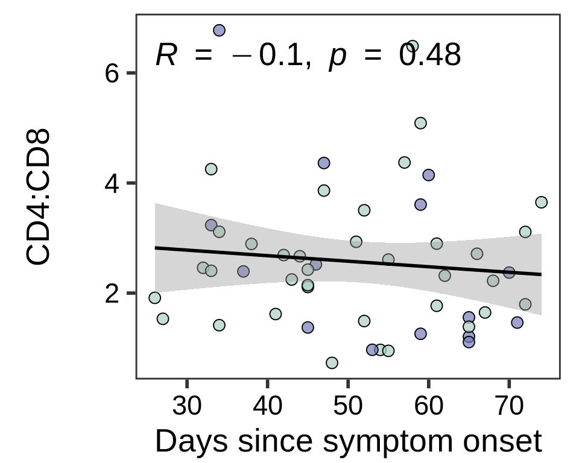

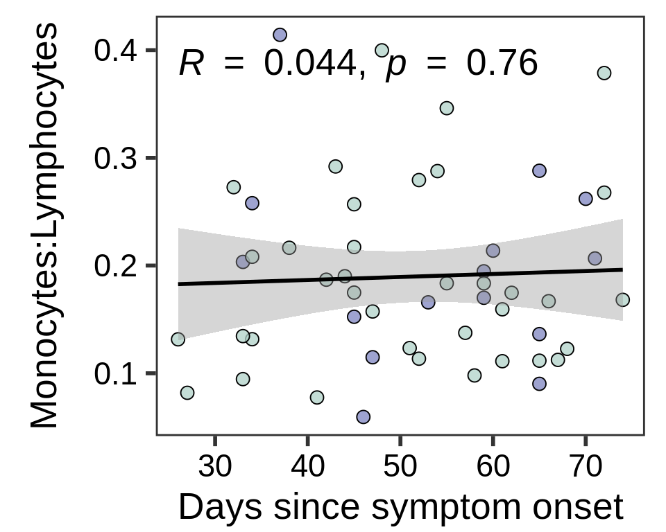

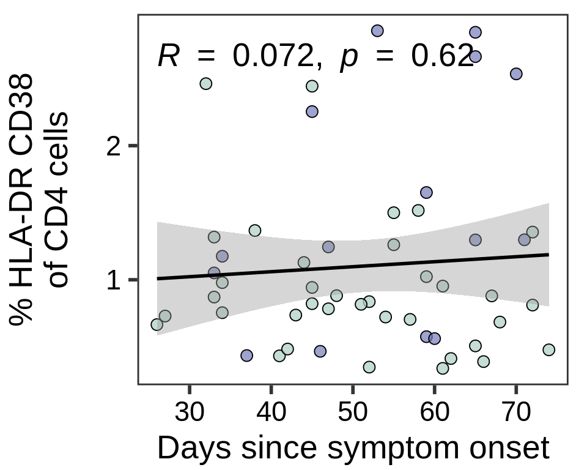

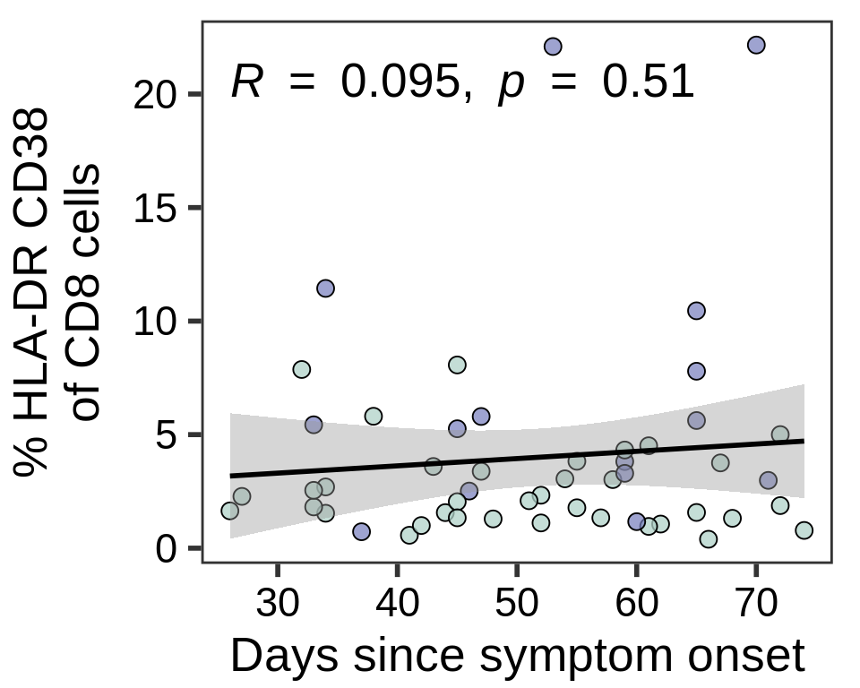

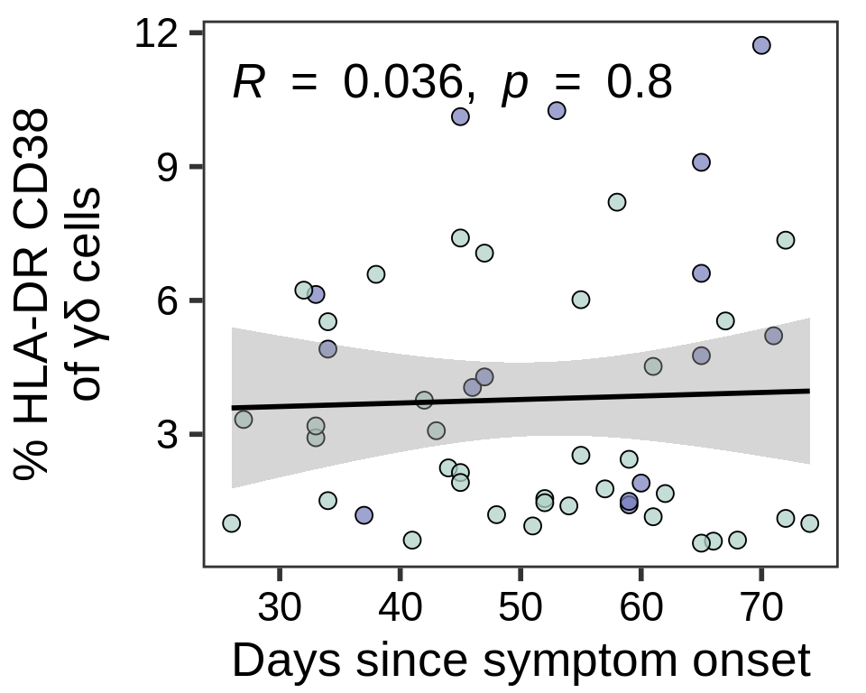

```r
plot_freq_vs_days <- function(col, include_stats_text=TRUE) {
  pop1 <- gsubfn(paste(names(text_sub_list),collapse="|"), text_sub_list, sub("(.*)_div_.*", "\\1", col))
  pop2 <- gsubfn(paste(names(text_sub_list),collapse="|"), text_sub_list, sub(".*_div_(.*)", "\\1", col))

  current_ylab <- if(col == "Monocytes_Lymphocytes_ratio")
    {"Monocytes:Lymphocytes"}
  else if(col == "CD4_CD8_ratio")
    {"CD4:CD8"}
  else
    {sprintf("%% %s\nof %s cells", sub("_", " ", pop1), pop2)}
  current_plot <- ggplot(pop_dat_sub, aes(Days_Symptom_Onset_to_Visit_1, !!as.symbol(col))) +
    theme_bw(base_size = 22) +
    geom_point(aes(fill=Cohort), pch=21, size=3) +
    theme(axis.title.x = element_text(size=20),
          axis.title.y = element_text(size=20),
          axis.text.y = element_text(color="black", size=17),
          axis.text.x = element_text(color="black", size=17),
          plot.title = element_blank(),
          panel.grid = element_blank(),
          legend.position = "none",
          plot.margin = margin(0.3, 0.4, 0.1, 0.2, "cm")) +
    labs(x = "Days since symptom onset",
         y = current_ylab) +
    # Linear regression line with 95% CI (based on "standard error of predicted means")
    scale_fill_manual(values = CohortColors) +
    geom_smooth(color = "black", method="lm")
  if(include_stats_text) {
    current_plot <- current_plot +
      # stat_cor from ggpubr
      stat_cor(method = "pearson", size=7)
  }
  if(!(col %in% c("Monocytes_Lymphocytes_ratio", "CD4_CD8_ratio"))) {
    current_plot <- current_plot + scale_y_continuous(labels = function(x) paste0(x*100))
  }
  current_plot
}

freqs_to_plot_vs_days <- c("T_div_Live", "CD4_div_T", "CD8_div_T", "CD4_CD8_ratio",
                "Monocytes_Lymphocytes_ratio", "HLADR_CD38_div_CD4", "HLADR_CD38_div_CD8", "HLADR_CD38_div_GD")
freqs_vs_days_plots <- lapply(freqs_to_plot_vs_days, plot_freq_vs_days)
names(freqs_vs_days_plots) <- freqs_to_plot_vs_days

# Make the width of all plots the same
# Help from here https://stackoverflow.com/a/41242871
gl <- lapply(freqs_vs_days_plots, ggplotGrob)
wd <- do.call(unit.pmax, lapply(gl, "[[", 'widths')) # Grab the width of the plot which has the largest width
freqs_vs_days_plots_grid <- lapply(gl, function(x) {
  x[['widths']] = wd
  x})
for(freq in freqs_to_plot_vs_days) {
  grid.arrange(freqs_vs_days_plots_grid[[freq]])
}
```

```r
freqs_vs_days_plots_no_stats_text <- lapply(freqs_to_plot_vs_days, plot_freq_vs_days, include_stats_text=FALSE)
names(freqs_vs_days_plots_no_stats_text) <- freqs_to_plot_vs_days
```

```r
# PDFs
if(save_output) {
  design <- c(
    # D
    area(t = 1, l = 1, b = 4, r = 3),
    area(t = 1, l = 4, b = 4, r = 8),
    # E
    area(t = 1, l = 9, b = 4, r = 11),
    area(t = 1, l = 12, b = 4, r = 16),
    # F
    area(t = 1, l = 17, b = 4, r = 19),
    area(t = 1, l = 20, b = 4, r = 24),
    # G
    area(t = 1, l = 25, b = 4, r = 27),
    area(t = 1, l = 28, b = 4, r = 30),

    # H
    area(t = 5, l = 1, b = 8, r = 3),
    area(t = 5, l = 4, b = 8, r = 8),
    # I
    area(t = 5, l = 9, b = 8, r = 11),
    area(t = 5, l = 12, b = 8, r = 16),
    # J
    area(t = 5, l = 17, b = 8, r = 19),
    area(t = 5, l = 20, b = 8, r = 22),
    # Spacer
    area(t = 5, l = 23, b = 8, r = 24),
    # K
    area(t = 5, l = 25, b = 8, r = 27),
    area(t = 5, l = 28, b = 8, r = 30)
    )

  cairo_pdf(file=here::here("out/Plots/Fig1DEFGHIJK_Surface_Marker_Freq_vs_Cohort_and_Days.pdf"),
            width=30, height=8, onefile = TRUE, bg = "transparent", family = "Arial")
  # 1st row
  freqs_vs_cohort_plots$T_div_Live + freqs_vs_days_plots_no_stats_text$T_div_Live +
    freqs_vs_cohort_plots$CD4_div_T + freqs_vs_days_plots_no_stats_text$CD4_div_T +
    freqs_vs_cohort_plots$CD8_div_T + freqs_vs_days_plots_no_stats_text$CD8_div_T +
      freqs_vs_cohort_plots$GD_div_T + freqs_vs_cohort_plots$Vd2_div_GD +
    # 2nd row
    freqs_vs_cohort_plots$HLADR_CD38_div_CD4 + freqs_vs_days_plots_no_stats_text$HLADR_CD38_div_CD4 +
    freqs_vs_cohort_plots$HLADR_CD38_div_CD8 + freqs_vs_days_plots_no_stats_text$HLADR_CD38_div_CD8 +
    freqs_vs_cohort_plots$Naive_div_CD4 + freqs_vs_cohort_plots$Naive_div_CD8 +
    plot_spacer() +
      freqs_vs_cohort_plots$HLADR_CD38_div_GD + freqs_vs_cohort_plots$HLADR_CD38_div_GD_Vd2Pos +
      plot_layout(design = design)
  dev.off()

  cairo_pdf(file=here::here("out/Plots/FigS4AB_Surface_Marker_Freq_vs_Cohort.pdf"),
            width=12, height=6, onefile = TRUE, bg = "transparent", family = "Arial")
  freqs_vs_cohort_plots$iNKT_div_T + freqs_vs_cohort_plots$HLADR_CD38_div_iNKT +
      freqs_vs_cohort_plots$MAIT_div_T + freqs_vs_cohort_plots$HLADR_CD38_div_MAIT +
    freqs_vs_cohort_plots$B_div_Live + freqs_vs_cohort_plots$Monocytes_div_Live +
    freqs_vs_cohort_plots$NK_div_Live + plot_spacer() +
      plot_layout(widths = rep(3, times = 4), heights = c(3, 3))
  dev.off()

  cairo_pdf(file=here::here("out/Plots/FigS4C_Activated_GD_vs_Days.pdf"),
          width=5, height=4, onefile = TRUE, bg = "transparent", family = "Arial")
  freqs_vs_days_plots_no_stats_text$HLADR_CD38_div_GD
  dev.off()
}
```